# Aula 25

## 5. Explorar atributos linguísticos

Vamos pegar uma palavra como exemplo.

```python
tweets_spacy[8]
```

```
sobre
```

Agora vamos ver os **82** atributos linguísticos disponíveis.

```
['ancestors',
 'check_flag',
 'children',
 'cluster',
 'conjuncts',
 'dep',
 'dep_',
 'doc',
 'ent_id',
 'ent_id_',
 'ent_iob',
 'ent_iob_',
 'ent_type',
 'ent_type_',
 'get_extension',
 'has_extension',
 'has_vector',
 'head',
 'i',
 'idx',
 'is_alpha',
 'is_ancestor',
 'is_ascii',
 'is_bracket',
 'is_currency',
 'is_digit',
 'is_left_punct',
 'is_lower',
 'is_oov',
 'is_punct',
 'is_quote',
 'is_right_punct',
 'is_sent_start',
 'is_space',
 'is_stop',
 'is_title',
 'is_upper',
 'lang',
 'lang_',
 'left_edge',
```

[output cut: 27 more lines]

```
 'shape',
 'shape_',
 'similarity',
 'string',
 'subtree',
 'suffix',
 'suffix_',
 'tag',
 'tag_',
 'text',
 'text_with_ws',
 'vector',
 'vector_norm',
 'vocab',
 'whitespace_']
```

Se você utilizar o índice da palavra **(.i)** você obtém um **ponto de dispersão**.

### > E o que a gente pode fazer com isso?

```python
tweets_spacy[8].i
```

```
8
```

### NÃO. Ainda não conseguimos fazer mágica.

[figure not shown]

### Mas que tal um gráfico de dispersão lexical? :)

[figure not shown]

Podemos plotar a dispersão lexical com as ocorrências de palavras, o mesmo que descrito no [livro do NLTK (capítulo 1)](https://www.nltk.org/book/ch01.html).

```python
from pylab import rcParams
```

Vamos criar um método para localizar as ocorrências de palavras.

```python
def localizar_palavra(agulha, palheiro):
    return pd.Series(np.histogram(
        [word.i for word in palheiro
         if word.text.lower() == agulha], bins=50)[0])
```

Vamos buscar por ocorrências de algumas palavras e plotá-las.

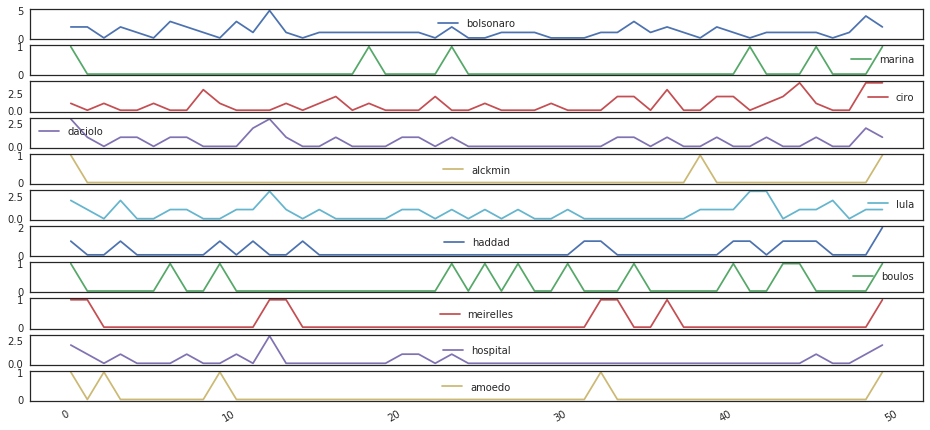

```python
rcParams['figure.figsize'] = 16, 8

pd.DataFrame(
    {name: localizar_palavra(name.lower(), tweets_spacy)
     for name in ['bolsonaro', 'marina', 'ciro', 'daciolo', 'alckmin', 'lula', 'haddad', 'boulos', 'meirelles',
                  'hospital', 'daciolo', 'amoedo']}
).plot(subplots=True)
plt.show()
```

### > Bolsonaro e hospital?

[figure not shown]

### > Cabo Daciolo?

[figure not shown]

### > Amoedo vs Alckmin?!

[figure not shown]

## 6. Reconhecimento de Entidades *(NER)*

Você também pode acessar [informações de NER](https://spacy.io/usage/linguistic-features#named-entities) pelo *doc.sents*.

Vamos listar as entidades reconhecidas nos *tweets*.

```
{'LOC', 'MISC', 'ORG', 'PER'}
```

O diferencial do spaCy é que, quando ele não possui anotações similares em seu *córpus*, ele utiliza um modelo treinado com base na [Wikipedia](https://spacy.io/usage/linguistic-features#named-entities) com as seguintes características genéricas:

- **PER**: nomes de pessoas e famílias;
- **LOC**: nome de localizações geográficas (*e.g.,* cidades, países, montanhas, etc);
- **ORG**: nomes de organizações corporativas, governamentais, etc;
- **MISC**: entidades diversas (*e.g.,* eventos, nacionalidades, produtos, peças de arte, etc).

Tem um [artigo disponível](https://www.sciencedirect.com/science/article/pii/S0004370212000276) para quem quiser entender como este modelo foi construído.

Vamos listar o que foi identificado como uma localização (**LOC**).

```python
[ent for ent in tweets_spacy.ents if ent.label_ == 'LOC']
```

```
[Transmissão,
 Arrisca,
 Querem,
 Bolsonaro,
 GazetaEstadaoJP,
 Bolsonaro,
 GazetaEstadaoJP,
 ,
                                                   ,
 GazetaEstadaoJP,
 GazetaEstadaoJP,
 Amoedo,
 Lembrando,
 Procede,
 Bolsonaro,
 Bolsonaro,
 GazetaEstadaoJP,
 Transmissão,
 Assista,
 GazetaEstadaoJP,
 Novo,
 Falta,
 GazetaEstadaoJP,
 ,
 Transmissão,
 Amoedo,
 Amanhã,
 Haddad,
 Bolsonaro,
 Cabo Daciolo,
 RT,
 GazetaEstadaoJP,
 GazetaEstadaoJP,
 Bolsonaro,
 RT,
 Procede,
 Bolsonaro,
 GazetaEstadaoJP,
                                                                                          ,
 Hoje,
```

[output cut: 337 more lines]

```
 Bolsonaro,
 ,
 Percebe,
 Cansei,
 Boulos,
 Mourão,
 GazetaEstadaoJP,
 Vem,
 GazetaEstadaoJP,
 GazetaEstadaoJP,
 Cirão,
 Bolsonaro,
 GazetaEstadaoJP,
 Brasil,
 R$]
```

Vamos ver quais sentenças possuem **"Bolsonaro"** rotulada como **LOC**.

```python
locs = [ent for ent in tweets_spacy.ents if ent.label_ == 'LOC' and ent.string.strip() == 'Bolsonaro']
[ent.sent for ent in locs]
```

```
[Lula na prisão, Bolsonaro no hospital, Daciolo de…
 5           , Lula na prisão, Bolsonaro no hospital, Daciolo de…
 8                 , Lembrando que já já 18h tem debate na Gazeta
 14          RT @SchuldinerSieg: Procede a informação de que o Mourão vai substituir o Bolsonaro no debate de hoje e nos posteriores?\n\nCaso sim, começo…
 15           RT @Ricamconsult:, Lula na prisão, Bolsonaro no hospital, Daciolo de…, Amanhã teremos um debate sem Lula (preso), Haddad (ainda no banco de reservas), Bolsonaro (hospitalizado) e Cabo Daciolo…, Lula na prisão, Bolsonaro no hospital, Daciolo de…
 41           , Procede a informação de que o Mourão vai substituir o Bolsonaro no debate de hoje e nos posteriores?\n\nCaso sim, começo…, Boulos tem que torcer pra Bolsonaro virar réu por Racismo.\n\nPq se a denúncia contra Bolsonaro for arquivada, Boulos tem que torcer pra Bolsonaro virar réu por …
 163         RT @SchuldinerSieg: Procede a informação de que o Mourão vai substituir o Bolsonaro no debate de hoje e nos posteriores?\n\nCaso sim, começo…, Procede a informação de que o Mourão vai substituir o Bolsonaro no debate de hoje e nos posteriores?\n\nCaso sim, começo…, No início do debate a…
 227                                            Gazeta promovendo o próprio debate, só assim para ganhar destaque sem o Bolsonaro., Bolsonaro obviamente não estará presente pois está internado vítima de um a…, Bolsonaro mete atestado para não ir a debate https://t.co/rLcrk0XseT
 8580                                                           , Bolsonaro mete atestado para não ir a debate https://t.co/rLcrk0XseT
 8595                                                                                                                      , Bolsonaro mete atestado para não ir a debate https://t.co/rLcrk0XseT, 8652                                     Debate sem o Daciolo e Bolsonaro não tem graça, tem que ter uns …
 8653                                                                                    , Bolsonaro mete atestado para não ir a debate https://t.co/rLcrk0XseT, Como é bom assistir um debate sem o Bolsonaro e o Cabo Daciolo., Bolsonaro mete atestado para não ir a debate https://t.co/rLcrk0XseT, Aman…
 8713                                    @exame Volto a dizer: Debate sem Bolsonaro, não é debate, é conversa de comadres., Em debate presidencial, @meirelles questionou @geraldoalckmin sobre seu programa de TV atacar Bolsonaro enquanto este ainda…, Bolsonaro mete atestado para não ir a debate, Bols…
 8806                                                   , Lula na prisão, Bolsonaro no hospital, Daciolo de…]
```

Vamos procurar também por um nome próprio para testar.

```python
per = [ent for ent in tweets_spacy.ents if ent.label_ == 'PER' and ent.string.strip() == 'Marina']
[ent.sent for ent in per]
```

```
[Gostaria muito de ver a Marina apoiar publicamente #,
 Teoricamente, Ciro e Marina estão empatados lutando pela segunda vaga no segundo turno.\n\nMas ficam se perguntando no debate se…,
 cirão da massa mandando um latim no debate enquanto profissional do Direito kkkk estranho seria caso contrário fosse
 8792         Marina, dizer que PT é igual ao PSDB assaltando Petrobras, Caixa, Correios, Banco do Brasil, BNDES não é correto.]
```

## 7. Visualizar Entidades

Uma das coisas mais legais do spaCy são as funcionalidades de visualização que ele fornece através do [**displacy**](https://spacy.io/usage/visualizers).

[figure not shown]

Vamos exibir os *tweets* com as entidades identificadas rotuladas.

Isso é feito através do método **render()** com a propriedade **style**:

```
style='ent'
```

Não esqueça de também setar a propriedade **jupyter** senão o spaCy tentará startar um novo serviço.

0 RT PER @MomentsBrasil: #Eleições2018 \n\nTudo sobre o debate entre os presidenciáveis de hoje 🗳 MISC ️ \n\n📺 Transmissão LOC em vídeo ao vivo no Twitter\n⚡ PER ️Twe MISC …  
1 RT @anyel PER : @pdevechi sem daciolo, sem debate.  
2 RT @dntav_ian PER : @pdevechi Arrisca LOC ser o debate mais produtivo do primeiro turno 3 MISC @bchartsnet Querem LOC ver ele em #1 ? divulgação é essencial pocs. Ciro PER 12 presidente. Hoje tem debate na TV gazeta as… https://t.co/7KdgLYcykI  
4 RT PER @Ricamconsult: Hoje à noite, teremos o debate presidencial mais esvaziado da História MISC . Lula na prisão, Bolsonaro LOC no hospital, Daciolo PER de…  
5 RT PER @joaoamoedonovo: Mais um debate que estamos de fora,apesar do apoio nas redes sociais e da petição com quase 700 mil assinaturas.\nDia 09 MISC …  
6 RT PER @JornalDaGazeta: Acompanhe PER os bastidores do debate # GazetaEstadaoJP LOC https://t.co/nMRhTHlQZo 7 MISC RT @Ricamconsult MISC : Hoje à noite, teremos o debate presidencial mais esvaziado da História MISC . Lula na prisão, Bolsonaro LOC no hospital, Daciolo PER de…  
8 Se avexe não, que debate com #Ciro12 é muito melhor! Logo mais na TV Gazeta MISC 18 horas! Ao vivo: https://t.co/SoK35zlX0R # GazetaEstadaoJP LOC LOC 9 LOC Hoje tem debate com esse cérebro!! #CiroPresidente12 #CIRO12 # GazetaEstadaoJP LOC https://t.co/t1AfvrdbCA  
10 RT @TwitterGov MISC : Não perca o debate entre os candidatos à Presidência do Brasil MISC , ao vivo, no Twitter MISC . 🇧 🇷 PER \n\n 📌 Hoje! MISC 9 de setembro, 2018\n🕕 18 h…  
11 # GazetaEstadaoJP LOC kd o Amoedo LOC no debate??? Não são a favor da mudança pelo jeito né. Chama lo não infringe nenhuma l… https://t.co/hyFS1z1EjQ  
12 ORG Por que não chamam o @joaoamoedonovo ??? Garanto PER que ele deixaria o debate interessante!!\n#VemComJoão30… https://t.co/m3Ob27LzQv  
13 RT @JenioQuadros: Lembrando LOC que já já 18h tem debate na Gazeta MISC 14 RT PER @SchuldinerSieg: Procede LOC a informação de que o Mourão MISC vai substituir o Bolsonaro LOC no debate de hoje e nos posteriores?\n\nCaso sim, começo…  
15 RT @Ricamconsult MISC : Hoje à noite, teremos o debate presidencial mais esvaziado da História MISC . Lula na prisão, Bolsonaro LOC no hospital, Daciolo PER de…  
16 RT PER @mhirase MISC : Hoje tem #Ciro12 no debate da # GazetaEstadaoJP https://t.co/EoDDOTaNhs ORG  
17 @JenioQuadros Vai ter live no YouTube MISC do debate?  
18 Daqui ORG a pouco tem debate!!!\nBora comparar as propostas galera!\n#GazetaEstadaoJP \n#Ciro12 \n#CiroPresidente12 \n#CiroNo2Turno  
19 #ciro12 Vai PER dar show no debate # GazetaEstadaoJP LOC  
20 RT PER @MomentsBrasil: #Eleições2018 \n\nTudo sobre o debate entre os presidenciáveis de hoje 🗳 MISC ️ \n\n📺 Transmissão LOC em vídeo ao vivo no Twitter\n⚡ PER ️Twe MISC …  
21 RT @TwitterGov MISC : Não perca o debate entre os candidatos à Presidência do Brasil MISC , ao vivo, no Twitter MISC . 🇧 🇷 PER \n\n 📌 Hoje! MISC 9 de setembro, 2018\n🕕 18 h…  
22 PER #Ciro12 debate na gazeta é Cirao da Massa MISC 23 Daqui MISC a pouco tem Ciro PER no…

## 8. Etiquetas Linguísticas *(Part-of-Speech Tagging)*

Talvez você já tenha ouvido falar sobre isso em sua abreviação **PoS**.

#### Atualmente:

### - O estado-da-arte para identificação de etiquetas de PoS no PennTree Bank (*córpus* em inglês bem famoso) chega a 97.3%$^{1}$

### - Estudos ainda mais recentes dizem ser possível atingir uma acurácia ainda maior com melhorias de taxonomias nos recursos linguísticos$^{2} $

Muita gente faz um monte de coisa de NLP legal, mas não aproveita os benefícios de **recursos linguísticos**.

Por exemplo: **contexto**.

Será que saber que "Bolsonaro" é um **PROPN** e o **sujeito** da frase não te ajuda a construir diálogos em seu *chatbot*? E saber os **ADJ** da sentença relacionados à ele?

### > Não entendeu as abreviações?

## Calma, meu jóvi.

[figure not shown]

A lista das etiquetas do spaCy está [aqui](https://github.com/explosion/spacy/blob/master/spacy/lang/pt/tag_map.py) e, apesar de não fornecerem descrições, tem variações bem próximas [às etiquetas do PennTree Bank](https://catalog.ldc.upenn.edu/docs/LDC99T42/tagguid1.pdf).

$^{1}$ [Adding Context Information to Part Of Speech: Tagging for Dialogues](https://hrilab.tufts.edu/publications/kubleretal10tlt.pdf), Sandra Kübler, Matthias Scheutz, Eric Baucom, Ross Israe; Indiana University  
$^{2}$ [Part-of-Speech Tagging from 97% to 100%: Is It Time for Some Linguistics?](https://nlp.stanford.edu/pubs/CICLing2011-manning-tagging.pdf), Christopher D. Manning, Stanford University

### Vamos listar as etiquetas encontradas nos *tweets*.

```
{92: 'NUM',
 102: 'SPACE',
 95: 'PROPN',
 83: 'ADJ',
 96: 'PUNCT',
 91: 'NOUN',
 85: 'ADV',
 84: 'ADP',
 89: 'DET',
 98: 'SYM',
 99: 'VERB',
 94: 'PRON',
 88: 'CCONJ',
 97: 'SCONJ',
 86: 'AUX',
 100: 'X'}
```

Vamos plotar a frequência de cada etiqueta linguística.

```python
tweets_pos = pd.Series(tweets_spacy.count_by(spacy.attrs.POS))/len(tweets_spacy)
```

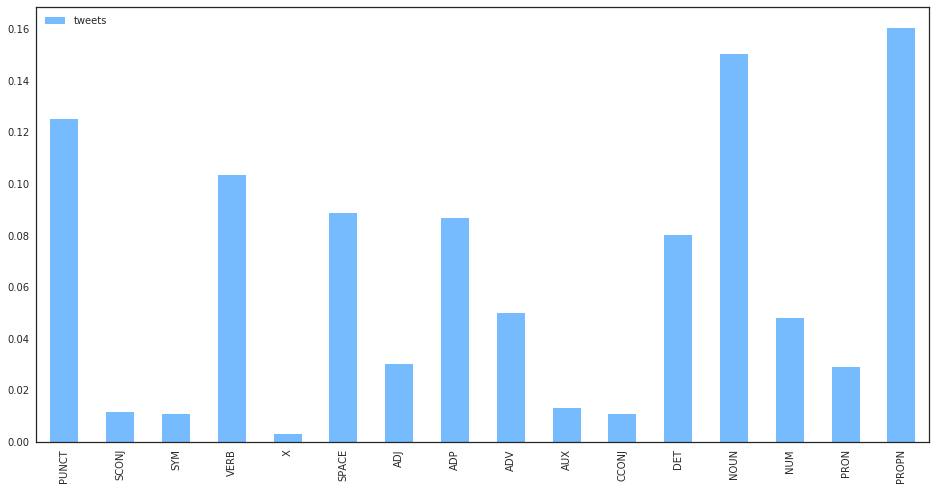

```python
rcParams['figure.figsize'] = 16, 8
df = pd.DataFrame([tweets_pos], index=['tweets'])
df.columns = [pos_dict[column] for column in df.columns]
df.T.plot(kind='bar', color='xkcd:sky blue')
plt.show()
```

Também podemos consultar quais os **adjetivos** mais comuns.

```python
from collections import Counter
```

Vamos ver o que foi rotulado como **PROPN**, a etiqueta com mais frequência.

```python
tweet_propn = [w for w in tweets_spacy if w.pos_ == 'PROPN']
Counter([w.string.strip() for w in tweet_propn]).most_common(10)
```

```
[('RT', 279),
 ('#', 197),
 ('GazetaEstadaoJP', 113),
 ('Gazeta', 62),
 ('Bolsonaro', 58),
 ('Ciro12', 50),
 ('Twitter', 48),
 ('TV', 46),
 ('Ciro', 37),
 ('Brasil', 36)]
```

Podemos também consultar os **adjetivos** mais frequentes nos *tweets*.

```
[('presidencial', 29),
 ('na', 18),
 ('@MomentsBrasil', 13),
 ('📺', 11),
 ('completa', 9),
 ('c', 9),
 ('@tvgazetaoficial', 7),
 ('presentes', 7),
 ('atento', 6),
 ('maior', 6)]
```

Ou ou **verbos** mais comuns.

```python
tweet_verb = [w for w in tweets_spacy if w.pos_ == 'VERB']
Counter([w.string.strip() for w in tweet_verb]).most_common(10)
```

```
[('tem', 65),
 ('é', 62),
 ('participam', 26),
 ('🇧', 22),
 ('teremos', 21),
 ('das', 21),
 ('RT', 19),
 ('acompanhe', 19),
 ('Acompanhe', 17),
 ('ver', 15)]
```

Vamos descobrir o que foi rotulado como **X**.

```python
tweet_x = [w for w in tweets_spacy if w.pos_ == 'X']
Counter([w.string.strip() for w in tweet_x]).most_common(10)
```

```
[('R$', 6),
 ('😴', 5),
 ('#', 4),
 ('o', 3),
 ('seja', 2),
 ('e', 1),
 ('nem', 1),
 ('in', 1),
 ('picture', 1),
 ('GazetaEstadaoJP', 1)]
```

Também podemos buscar por **sentenças** ao invés de **palavras**.

```python
Counter([w.string.strip() for w in tweets_spacy.ents if w.label_ == 'PER']).most_common(10)
```

```
[('RT', 115),
 ('', 28),
 ('Acompanhe', 21),
 ('Ciro', 20),
 ('Daciolo', 17),
 ('Ciro Gomes', 15),
 ('RT @Estadao:', 14),
 ('🇷', 13),
 ('Twitter\\n⚡', 11),
 ('RT @cirogomes', 11)]
```

Uma das técnicas mais importantes de NLP, apesar de não tão conhecida, é a análise e processamento de **árvores sintáticas**.

## > JESUS, O QUE É ISSO?!

[figure not shown]

Vamos utilizar uma sentença como exemplo.

### ATENÇÃO: não esqueça de adicionar o caracter "u" antes da frase para identificá-la como unicode e ser aceita como entrada pelo método nlp() do spaCy!

```python
parsetree_sent = nlp(u' Não aguento mais essa aula, eu nunca quiser aprender isso na vida. A Rayssa é chata e a aula está ruim')
```

Vamos ver as etiquetas identificadas:

```
{102: 'SPACE',
 85: 'ADV',
 99: 'VERB',
 89: 'DET',
 91: 'NOUN',
 96: 'PUNCT',
 94: 'PRON',
 95: 'PROPN',
 83: 'ADJ',
 88: 'CCONJ'}
```

### > Qual o **PROPN**?

*"Não aguento mais essa aula, eu nunca quiser aprender isso na vida. A Rayssa é chata e a aula está ruim"*

```python
parsetree_propn = [w for w in parsetree_sent if w.pos_ == 'PROPN']
Counter([w.string.strip() for w in parsetree_propn])
```

```
Counter({'Rayssa': 1})
```

### > Quais os **NOUN's**?

*"Não aguento mais essa aula, eu nunca quiser aprender isso na vida. A Rayssa é chata e a aula está ruim"*

```python
parsetree_noun = [w for w in parsetree_sent if w.pos_ == 'NOUN']
Counter([w.string.strip() for w in parsetree_noun])
```

```
Counter({'aula': 2, 'vida': 1})
```

### > Quais os **ADJ's**?

*"Não aguento mais essa aula, eu nunca quiser aprender isso na vida. A Rayssa é chata e a aula está ruim"*

```python
parsetree_adj = [w for w in parsetree_sent if w.pos_ == 'ADJ']
Counter([w.string.strip() for w in parsetree_adj])
```

```
Counter({'chata': 1, 'ruim': 1})
```

### > Quais os **VB's**?

*"Não aguento mais essa aula, eu nunca quiser aprender isso na vida. A Rayssa é chata e a aula está ruim"*

```python
parsetree_vb = [w for w in parsetree_sent if w.pos_ == 'VERB']
Counter([w.string.strip() for w in parsetree_vb])
```

```
Counter({'aguento': 1, 'quiser': 1, 'aprender': 1, 'é': 1, 'está': 1})
```

### > Quais os **DET's**?

*"Não aguento mais essa aula, eu nunca quiser aprender isso na vida. A Rayssa é chata e a aula está ruim"*

```python
parsetree_det = [w for w in parsetree_sent if w.pos_ == 'DET']
Counter([w.string.strip() for w in parsetree_det])
```

```
Counter({'essa': 1, 'na': 1, 'A': 1, 'a': 1})
```

### > Quais os **ADV's**?

*"Não aguento mais essa aula, eu nunca quiser aprender isso na vida. A Rayssa é chata e a aula está ruim"*

```python
parsetree_conj = [w for w in parsetree_sent if w.pos_ == 'ADV']
Counter([w.string.strip() for w in parsetree_conj])
```

```
Counter({'Não': 1, 'mais': 1, 'nunca': 1})
```

### > Quais os **PRON's**?

*"Não aguento mais essa aula, eu nunca quiser aprender isso na vida. A Rayssa é chata e a aula está ruim"*

```python
parsetree_conj = [w for w in parsetree_sent if w.pos_ == 'PRON']
Counter([w.string.strip() for w in parsetree_conj])
```

```
Counter({'eu': 1, 'isso': 1})
```

### > Quais os **CCONJ's**?

*"Não aguento mais essa aula, eu nunca quiser aprender isso na vida. A Rayssa é chata e a aula está ruim"*

```python
parsetree_conj = [w for w in parsetree_sent if w.pos_ == 'CCONJ']
Counter([w.string.strip() for w in parsetree_conj])
```

```
Counter({'e': 1})
```

### > Quais as **PUNCT's**?

*"Não aguento mais essa aula, eu nunca quiser aprender isso na vida. A Rayssa é chata e a aula está ruim"*

```python
parsetree_conj = [w for w in parsetree_sent if w.pos_ == 'PUNCT']
Counter([w.string.strip() for w in parsetree_conj])
```

```
Counter({',': 1, '.': 1})
```

### > Quais os **SPACE's**?

*"Não aguento mais essa aula, eu nunca quiser aprender isso na vida. A Rayssa é chata e a aula está ruim"*

```python
parsetree_conj = [w for w in parsetree_sent if w.pos_ == 'SPACE']
Counter([w.string.strip() for w in parsetree_conj])
```

```
Counter({'': 1})
```

# Todas as palavras estão ligadas

Você estudou **sintaxe** nas aulas de Língua Portuguesa na escola, certo? *(diz que sim, pfv)*

Então sabe que todas as palavras estão ligadas e você consegue dizer quais são as ligações, mesmo que não saiba dizer a **semântica** das palavras.

## > Você vai precisar relembrar suas aulas e estudar a linguística do Português!

Eu não tenho vergonha de assumir que tenho **três** livros de Língua Portuguese de ensino médio.

[figure not shown]

# Árvores Sintáticas

A técnica que mencionei nada mais é do que uma representação das etiquetas de PoS e as ligações entre as palavras.

Novamente, o spaCy é **muito(!) legal** e fornece uma visualização pronta **(e bonita)** para que você não precise construir na mão. Ao contrário do NLTK que printa uma árvore com caracteres, não imagens.

**ACREDITE**: *é **muito(!)** trabalhoso fazer isso na mão!*

Isso também é feito através do método **render()**, porém com a propriedade **style** setada como:

```
style='dep'
```

[figure not shown]

Você pode ajustar algumas opções também:

```python
options = {'compact': True, 'color': 'white', 'bg':'lightblue'}
```

[figure not shown]

# Pausa!

[figure not shown]

# ...voltando às sentenças

### Vamos ver o que a galerinha andou falando do Bolsonaro.

[figure not shown]

```python
bolsonaro_sents
```

```
[Lula na prisão, Bolsonaro no hospital, Daciolo de…
 5           , Lula na prisão, Bolsonaro no hospital, Daciolo de…
 8                 , Lembrando que já já 18h tem debate na Gazeta
 14          RT @SchuldinerSieg: Procede a informação de que o Mourão vai substituir o Bolsonaro no debate de hoje e nos posteriores?\n\nCaso sim, começo…
 15           RT @Ricamconsult:, Lula na prisão, Bolsonaro no hospital, Daciolo de…, Amanhã teremos um debate sem Lula (preso), Haddad (ainda no banco de reservas), Bolsonaro (hospitalizado) e Cabo Daciolo…, Lula na prisão, Bolsonaro no hospital, Daciolo de…
 41           , Procede a informação de que o Mourão vai substituir o Bolsonaro no debate de hoje e nos posteriores?\n\nCaso sim, começo…, Boulos tem que torcer pra Bolsonaro virar réu por Racismo.\n\nPq se a denúncia contra Bolsonaro for arquivada, Amanhã teremos um debate sem Lula (preso), Haddad …
 163         RT @SchuldinerSieg: Procede a informação de que o Mourão vai substituir o Bolsonaro no debate de hoje e nos posteriores?\n\nCaso sim, começo…, Procede a informação de que o Mourão vai substituir o Bolsonaro no debate de hoje e nos posteriores?\n\nCaso sim, começo…, No início do debate a…
 227                                            Gazeta promovendo o próprio debate, só assim para ganhar destaque sem o Bolsonaro., Bolsonaro obviamente não estará presente pois está internado vítima de um a…, Bolsonaro mete atestado para não ir a debate https://t.co/rLcrk0XseT
 8580                                                           , Bolsonaro mete atestado para não ir a debate https://t.co/rLcrk0XseT
 8595                                                                                                                      , Debate sem Bolsonaro não é debate., Equipe de Alvaro Dias acha que ausência de Bolsonaro e Daciolo lhe dá mais espaço no debate, Debate acontece hoje às 18h e não conta com a …
 8653                                                                                    , Bolsonaro mete atestado para não ir a debate https://t.co/rLcrk0XseT, Como é bom assistir um debate sem o Bolsonaro e o Cabo Daciolo., Bolsonaro mete atestado para não ir a debate https://t.co/rLcrk0XseT, 8688…
 8689         RT @elpais_brasil:, @jairbolsonaro vai ganhar essa eleição, a despeito do desrespeito dos canalhas, que e… https://t.co/m5ehd8asIC
 8692       , Amanhã teremos um debate sem Lula (preso), Haddad (ainda no banco de reservas), Bolsonaro (hospitalizado) e Cabo Daciolo…, https://t.co/z3QCQj6m8n
 8713                                    @exame Volto a dizer: Debate sem Bolsonaro, não é debate, é conversa de comadres., Em debate presidencial, @meirelles questionou @geraldoalckmin sobre seu programa de TV atacar Bolsonaro enquanto este ainda…, Bolsonaro mete atestado para não ir a debate, Bols…
 8806                                                   , Debate sem Bolsonaro e Mourão é golpe...., Lula na prisão, Bolsonaro no hospital, Daciolo de…]
```

Você também pode printar a árvore sintática **bruta** apenas com caracteres (beijo, NLTK)

```python
for word in bolsonaro_sents[3]:
    print(word, word.tag_, word.pos_)
```

```
Lula PROP|M|S|@SUBJ> PROPN
na ADJ|F|S|@>N ADJ
prisão <np-idf>|N|F|S|@N<PRED NOUN
, PU|@PU PUNCT
Bolsonaro PROP|M|S|@SUBJ> PROPN
no PERS|M|3S|ACC|@<ACC PRON
hospital <np-idf>|N|M|S|@<ACC NOUN
, PU|@PU PUNCT
Daciolo PROP|M|S|@N<PRED PROPN
de PRP|@N< ADP
… PU|@PU PUNCT

  SPACE
```

Você também pode consultar **a raiz e os nós** de uma árvore sintática

```
[na, prisão, ,, Bolsonaro]
```

Vemos ver todos os nós de cada palavra:

```python
for word in bolsonaro_sents[3]:
    print(word, ': ', str(list(word.children)))
```

```
Lula :  [na, prisão, ,, Bolsonaro]
na :  []
prisão :  []
, :  []
Bolsonaro :  [no, hospital, Daciolo]
no :  []
hospital :  []
, :  []
Daciolo :  [,, …]
de :  []
… :  [de,
]

 :  []
```

### E quais **VERB** descrevem o Bolsonaro?

```
tem
Procede
substituir
posteriores?\n\nCaso
preso
hospitalizado
substituir
posteriores?\n\nCaso
virar
arquivada
preso
hospitalizado
é
substituir
posteriores?\n\nCaso
substituir
posteriores?\n\nCaso
ver
pesar
quer
culpar
internado
ganhar
comparem
terá
preso
hospitalizado
virar
arquivada
preso
hospitalizado
é
é
preso
hospitalizado
Procede
substituir
posteriores?\n\nCaso
substituir
posteriores?\n\nCaso
```

[output cut: 39 more lines]

```
atestado
ir
Vendo
precisa
pagando
estar
subir
falando
atestado
ir
é
assistir
atestado
ir
é
```

### Vamos ver o que foi falado sobre o **Lula**.

[figure not shown]

```python
lula_sents = [sent for sent in tweets_spacy.sents if 'lula' in sent.string.lower()]
```

```python
lula_sents
```

```
[Lula na prisão, Bolsonaro no hospital, Daciolo de…
 5           , Lula na prisão, Bolsonaro no hospital, Daciolo de…
 8                 , Lula na prisão, Bolsonaro no hospital, Daciolo de…, Amanhã teremos um debate sem Lula (preso), Haddad (ainda no banco de reservas), Bolsonaro (hospitalizado) e Cabo Daciolo…, Lula na prisão, Bolsonaro no hospital, Daciolo de…
 41           , Amanhã teremos um debate sem Lula (preso), Haddad (ainda no banco de reservas), Bolsonaro (hospitalizado) e Cabo Daciolo…, Lula na prisão, Bolsonaro no hospital, Daciolo de…, sem #HaddadéLula , nem #bronhonaro ... #, EuSoulula  e vou assistir, mas só p… https://t.co/ZyCslsiMEQ, Lula …
 8759                                                                                         , Lula na prisão, Bolsonaro no hospital, Daciolo de…, 8769          @cirogomes defende @LulaOficial no debate da @tvgazetaoficial., GazetaEstadaoJP:\n- Lula (preso em Curitiba)\n- Haddad (não é debate de v……
```

```python
for word in lula_sents[2]:
    print(word, word.tag_, word.pos_)
```

```
Lula PROP|M|S|@SUBJ> PROPN
na ADJ|F|S|@>N ADJ
prisão <np-idf>|N|F|S|@N<PRED NOUN
, PU|@PU PUNCT
Bolsonaro PROP|M|S|@SUBJ> PROPN
no PERS|M|3S|ACC|@<ACC PRON
hospital <np-idf>|N|M|S|@<ACC NOUN
, PU|@PU PUNCT
Daciolo PROP|M|S|@N<PRED PROPN
de PRP|@N< ADP
… PU|@PU PUNCT

  SPACE
```

### E quais **NOUN** descrevem o Lula?

```python
for sent in lula_sents:
    for word in sent:
        for child in word.children:
            if child.pos_ == 'NOUN':
                print(child)
```

```
prisão
hospital
prisão
hospital
prisão
hospital
debate
banco
reservas
prisão
hospital
debate
banco
reservas
prisão
hospital
#
https://t.co/ZyCslsiMEQ
prisão
hospital
debate
banco
reservas
prisão
hospital
prisão
hospital
prisão
hospital
debate
banco
reservas
debate
banco
reservas
prisão
hospital
prisão
hospital
prisão
```

[output cut: 15 more lines]

```
debate
ciro
lula
debate
prisão
hospital
@cirogomes
@LulaOficial
debate
debate
debate
prisão
hospital
prisão
hospital
```

### E sobre Marina?

[figure not shown]

```python
marina_sents = [sent for sent in tweets_spacy.sents if 'marina' in sent.string.lower()]
```

```python
marina_sents
```

```
[Fiquem de olho e vamos juntos com Marina.\n#MarinaSilva, Marina18
 159       RT @TwitterGov:, 175          RT @MarinaSilva:, 233          RT @MarinaSilva:, 234                      @MarinaSilva, Gostaria muito de ver a Marina apoiar publicamente #, @MarinaSilva:, Teoricamente, Ciro e Marina estão empatados lutando pela segunda vaga no segundo turno.\n\nMas ficam s…
 8792         Marina, dizer que PT é igual ao PSDB assaltando Petrobras, Caixa, Correios, Banco do Brasil, BNDES não é correto.]
```

### E quais **ADJ** descrevem a Marina?

```python
for sent in marina_sents:
    for word in sent:
        for child in word.children:
            if child.pos_ == 'ADJ':
                print(child)
```

```
segunda
segundo
profissional
estranho
igual
```

### E sobre João Amoedo? #queremosAmoedoNosDebates

[figure not shown]

```python
amoedo_sents = [sent for sent in tweets_spacy.sents if 'amoedo' in sent.string.lower()]
```

```python
amoedo_sents
```

```
[RT @joaoamoedonovo:,
 11           #GazetaEstadaoJP kd o Amoedo no debate??,
 Por que não chamam o @joaoamoedonovo ??,
 O Debate está chegando e o candidato @joaoamoedonovo ainda não foi convidado…,
 @joaoamoedonovo #joaonosde…,
 Com exceção do Amoedo, a ausência dos outros só vai melhorar a qualidade do debate https://t.co/jeVsLLfw3n
 34        ,
 Totalmente ridículo!\n#AmoedoNosDebates \n#VemComJoão30,
 Principalmente o João Amoedo
 90                                                               ,
 #GazetaEstadaoJP já que JB não participará (força pra ele) acredito que nada mais justo finalmente chamarem @joaoamoedo…,
 Sim, eu quero #JoãoAmoedo,
 @joaoamoedonovo no,
 E o @joaoamoedonovo ??,
 Sem o @joaoamoedonovo?,
 Ninguém convida o @joaoamoedonovo pro debate, mesmo quando faltam participantes...,
 Vou aguardar o debate da @VEJA , com a participação do @joaoamoedonovo .,
 E o @joaoamoedonovo ??,
 \n#AmoedoNosDebates #Joao…,
 O Debate está chegando e o candidato @joaoamoedonovo ainda não foi convidado…,
 Cadê o @joaoamoedonovo do @partidonovo30?,
 Sem o @joaoamoedonovo?,
 Queremos o @joaoamoedonovo nos debates!,
 Queremos o @joaoamoedonovo nos debates!,
 Faltou o @joaoamoedonovo #,
 Lá vamos nós outra vez, ver @joaoamoedonovo fora de mais um debate enquanto que é o assunto mais…,
 RT @joaoamoedonovo:,
 RT @DomenicoRussoJr: @mandafss debate sem Amoedo e com Boulos e Daciolo\n\nme,
 https://t.co/FELFiQlKJ5
 8763         Infelizmente,@joaoamoedonovo , não esta em mais um debate,ainda mais agora, que outros candidatos estão se apropria,
 Cadê o João Amoedo nesse debate?\n#amoedonosdebates \n#GazetaEstadaoJP
 8776       RT @Desesquerdizada:]
```

### E quais **ADJ** descrevem Amoedo?

```python
for sent in amoedo_sents:
    for word in sent:
        for child in word.children:
            if child.pos_ == 'ADJ':
                print(child)
```

```
justo
\n#GazetaEstadaoJP
```

## Vamos brincar com verbos e palavras

Este método vai buscar verbos (TOP20) relacionados à uma palavra informada.

```python
def verbs_characters(text, character):
    sents = [sent for sent in text.sents if character in sent.string]
    char_words = []
    for sent in sents:
        for word in sent:
            if character in word.string:
                char_words.append(word)
    char_verbs = []
    for word in char_words:
        for ancestor in word.ancestors:
            if ancestor.pos_.startswith('V'):
                char_verbs.append(ancestor.lemma_.strip())
    return Counter(char_verbs).most_common(20)
```

Vamos guardar algumas buscas:

```python
bolsonaro_verbs = verbs_characters(tweets_spacy, 'Bolsonaro')
bolsonaro_verbs
```

```
[('ter', 8),
 ('substituir', 7),
 ('Procede', 6),
 ('torcer', 4),
 ('arquivar', 2),
 ('ganhar', 2),
 ('assistir', 2),
 ('Lembrando', 1),
 ('representar', 1),
 ('saber', 1),
 ('promover', 1),
 ('https://t.co/qfN4QyuWqb', 1),
 ('dar', 1),
 ('achar', 1),
 ('contar', 1),
 ('acontecer', 1),
 ('@MidiaNINJA', 1),
 ('atacar', 1),
 ('questionar', 1),
 ('falar', 1)]
```

```python
marina_verbs = verbs_characters(tweets_spacy, 'Marina')
marina_verbs
```

```
[('dizer', 2),
 ('ir', 1),
 ('Fiquem', 1),
 ('apoiar', 1),
 ('empatar', 1),
 ('botar', 1)]
```

```python
amoedo_verbs = verbs_characters(tweets_spacy, 'Amoedo')
amoedo_verbs
```

```
[('melhorar', 1), ('querer', 1)]
```

```python
daciolo_verbs = verbs_characters(tweets_spacy, 'Daciolo')
daciolo_verbs
```

```
[('ter', 7),
 ('assistir', 2),
 ('dar', 1),
 ('achar', 1),
 ('anunciar', 1),
 ('tirar', 1)]
```

```python
boulos_verbs = verbs_characters(tweets_spacy, 'Boulos')
boulos_verbs
```

```
[('tipo', 3),
 ('ter', 2),
 ('torcer', 2),
 ('participar', 2),
 ('arrasar', 2),
 ('comedir', 1),
 ('insinuar', 1),
 ('tentar', 1),
 ('economizar', 1),
 ('@MidiaNINJA', 1),
 ('responder', 1),
 ('salvo', 1)]
```

```python
brasil_verbs = verbs_characters(tweets_spacy, 'brasil')
brasil_verbs
```

```
[('promover', 1)]
```

Agora vamos plotar essas informações, a função abaixo apenas constrói um *dataframe* para facilitar.

```python
def verbs_matrix(verb_counts):
    return pd.Series({t[0]: t[1] for t in verb_counts})
```

- O verbo **"ter"** é o mais frequente, e diz respeito ao **"Bolsonaro"** e **"Daciolo"**
- **"dizer"** de **"Marina"**
- **"tentar"**, **"participar"** e **"arrasaar"** do **"Boulos"**
- **"querer"** e **"melhorar"** de **"Amoedo"**

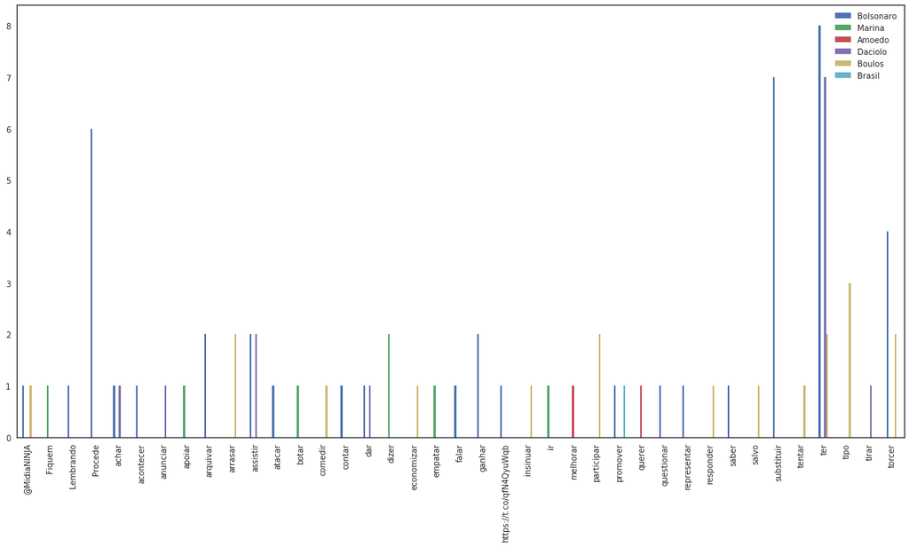

```python
verbs_df = pd.DataFrame({'Bolsonaro': verbs_matrix(bolsonaro_verbs),
                        'Marina': verbs_matrix(marina_verbs),
                        'Amoedo': verbs_matrix(amoedo_verbs),
                        'Daciolo': verbs_matrix(daciolo_verbs),
                        'Boulos': verbs_matrix(boulos_verbs),
                        'Brasil': verbs_matrix(brasil_verbs)}).fillna(0)
verbs_df.plot(kind='bar', figsize=(20,10))
plt.show()
```

## 9. Vetores de palavras *(word embeddings)*$^{1}$

### O que é?

O computador, em si, não interpreta textos, certo? Então como processar Língua Natural?

Precisamos transformar estes textos em **valores numéricos representativos.**

Existem diversas técnicas para isso, mas todas são formas de construir uma representação numérica para cada palavra em seu *córpus*. E, como em uma **sentença** temos diversas palavras, cada sentença vai possuir um **vetor** de valores numéricos para representar as palavras de uma sentença.

Mas como isso nos ajuda **na prática**?

#### Complete a seguinte frase:

[figure not shown]

#### Um bom modelo treinado deve ser capaz de extrair informações de conceitos e significados das palavras:

[figure not shown]

### Tipos de técnicas

1. *Bag of Words* (BoW)
2. BoW + TF-IDF
3. *Continuous Bag of Words* (CBOW)
4. *Skip-gram*
5. *Global Vectors* ([GloVe](https://nlp.stanford.edu/pubs/glove.pdf))

### Vamos focar em BoW + TF-IDF nesta aula por limitações de tempo, ok?

#### Quem quiser material sobre os demais é só me avisar!

[figure not shown]

O BoW tradicional nada mais é do que uma representação numérica de palavras em um vetor com valores binários: **presença** ou **ausência** de palavra em cada sentença, dadas todas as palavras de um *córpus*.

Apenas a existência ou não de uma palavra não se provou ser suficiente e, com o tempo, foi adotada a estratégia de **contar ocorrências** de palavras.

É o famoso **term-frequency** (TF)$^{2}$, onde a frequência de uma palavra \textbf{p} é calculada dividindo-se sua frequência pelo número total de palavras em um conjunto de documentos:

\begin{align} \label{math:tf} TF(p) = \frac{quantidade\ de\ \textbf{p}\ no\ documento}{total\ de\ palavras\ no\ documento} \end{align}

**Na prática?** Vamos supor que tenhamos três frases:

1. Eu amo chocolate
2. Ele gosta de dormir
3. Eu amo viajar

Nosso *córpus* é o conjunto de todas estas palavras:

\begin{equation*} \mathbf{X} = \begin{array}{cc} \\ \mathit{eu} \\ \mathit{amo} \\ \mathit{chocolate} \\ \mathit{ele} \\ \mathit{gosta} \\ \mathit{de} \\ \mathit{dormir} \\ \mathit{eu} \\ \mathit{amo} \\ \mathit{viajar} \\ \end{array} \begin{bmatrix} \begin{array}{c} & \mathit{eu} & \mathit{amo} & \mathit{chocolate} & \mathit{ele} & \mathit{gosta} & \mathit{de} & \mathit{dormir} & \mathit{eu} & \mathit{amo} & \mathit{viajar}\\ & 0 & 2 & 0 & 0 & 0 & 0 & 0 & 0 & 0 & 0 \\ & 2 & 0 & 1 & 0 & 0 & 0 & 0 & 0 & 0 & 1 \\ & 0 & 1 & 0 & 0 & 0 & 0 & 0 & 0 & 0 & 0 \\ & 0 & 0 & 0 & 0 & 1 & 0 & 0 & 0 & 0 & 0 \\ & 0 & 0 & 0 & 1 & 0 & 1 & 0 & 0 & 0 & 0 \\ & 0 & 0 & 0 & 0 & 1 & 0 & 1 & 0 & 0 & 0 \\ & 0 & 0 & 0 & 0 & 0 & 1 & 0 & 0 & 0 & 0 \\ & 0 & 0 & 0 & 0 & 0 & 0 & 0 & 0 & 0 & 0 \\ & 0 & 0 & 1 & 0 & 0 & 0 & 0 & 0 & 0 & 1 \\ & 0 & 1 & 0 & 0 & 0 & 0 & 0 & 0 & 1 & 0 \\ \end{array} \end{bmatrix} \end{equation*}

Porém, as palavras mais frequentes não são necessariamente as mais **relevantes**.

Considere a palavra \textit{"que"} da língua Portuguesa. É uma das palavras mais frequentes no vocabulário, porém, não tem relevância **semântica** na maioria dos casos. Apenas a frequência de uma palavra não é suficiente para calcular sua relevância.

### E as palavras MENOS utilizadas?

Maior probabilidade de terem um significado semântico dentro de um contexto de vários documentos!

E este é o famoso **inverse document frequency** (IDF)$^{3}$:

\begin{align} \label{math:idf} IDF(p) = log_e(\frac{quantidade\ de\ documentos}{total\ de\ documentos\ com\ \textbf{p}}) \end{align}

$^{1}$[Modern_NLP_in_Python](http://nbviewer.jupyter.org/github/skipgram/modern-nlp-in-python/blob/master/executable/Modern_NLP_in_Python.ipynb#topic=0&lambda=0.6&term=)* $^{2}$[Term frequency and weighting](https://nlp.stanford.edu/IR-book/html/htmledition/term-frequency-and-weighting-1.html)* $^{3}$[Inverse document frequency](https://nlp.stanford.edu/IR-book/html/htmledition/inverse-document-frequency-1.html)*

# Similaridade de palavras

Uma coisa legal que conseguimos fazer através destes vetores de palavras é calcular a **similaridade** entre palavras.

Vamos testar algumas palavras.

```python
bolsonaro, marina, amoedo, daciolo, lula, mudanca = nlp('bolsonaro'), nlp('marina'), nlp('amoedo'), \
                                                     nlp('daciolo'), nlp('lula'), nlp('mudança')
```

Qual a similaridade entre as palavras "Bolsonaro" e "mudança"?

```python
bolsonaro.similarity(mudanca)
```

```
0.5578938274142293
```

Qual a similaridade entre as palavras "Marina" e "mudança"?

```python
marina.similarity(mudanca)
```

```
0.6215873749295959
```

Qual a similaridade entre as palavras "Lula" e "mudança"?

```python
lula.similarity(mudanca)
```

```
0.6166460223741975
```

Qual a similaridade entre as palavras "Daciolo" e "mudança"?

```python
daciolo.similarity(mudanca)
```

```
0.6484602718110165
```

Qual a similaridade entre as palavras "Amoedo" e "mudança"?

```python
amoedo.similarity(mudanca)
```

```
0.6086239112606606
```

#### Um exemplo mais realista sobre a aplicação de similaridade semântica.

```
0.7786461143691964
```

## Vamos ver os vetores de NOUN's dos *tweets*

Primeiro vamos pegar os NOUN's, em si.

```python
tweets_nouns = [word for word in tweets_spacy if word.pos_.startswith('N')][:150]
```

```python
tweets_nouns
```

```
[0,
 #,
 \n\nTudo,
 debate,
 🗳,
 Transmissão,
 vídeo,
 vivo,
 1,
 daciolo,
 debate,
 2,
 @dntav_ian,
 debate,
 turno,
 3,
 #,
 1,
 divulgação,
 12,
 presidente,
 debate,
 TV,
 4,
 noite,
 debate,
 prisão,
 hospital,
 5,
 um,
 debate,
 apoio,
 redes,
 petição,
 700,
 mil,
 assinaturas.\nDia,
 09,
 6,
 debate,
```

[output cut: 95 more lines]

```
 GazetaEstadaoJP,
 debate,
 novo,
 27,
 pro,
 debate,
 18h,
 #,
 28,
 debate,
 29,
 @GuilhermeBoulos,
 pro,
 debate,
 pouco]
```

Agora vamos mapear o vetor.

```python
tweets_noun_vecs = [word.vector for word in tweets_nouns if len(word)>2]
tweets_noun_labels = [word.string.strip() for word in tweets_nouns if len(word)>2]
```

Temos um vetor de 384 dimensões.

```python
tweets_noun_vecs[0].shape
```

```
(384,)
```

Vamos printar o vetor.

```python
tweets_noun_vecs
```

```
[array([ 13.051941  ,  -4.4398656 ,   3.0288486 ,  -0.9797137 ,
         -5.6467695 ,   6.645371  ,   2.254023  ,  -6.8102684 ,
          1.0175691 ,  -1.2665282 ,   3.2975378 ,   5.0549583 ,
         -4.481613  ,  -0.0382632 ,  -6.0393248 ,   0.78619677,
         -7.561641  ,  -0.04681802,  -0.9197228 ,   1.4321665 ,
         -2.275153  ,  -7.9878945 ,   0.89128053,  -1.6613508 ,
         -2.8093135 ,   2.0344353 ,  -1.5944062 ,  -1.6212004 ,
         -1.0826095 , -10.102079  ,  -7.6569767 ,  -6.085317  ,
          0.09642875,   1.3511205 ,  -2.6385424 ,  -0.73986   ,
        -12.247275  ,   6.275188  ,  -1.0034115 ,  -1.867907  ,
         -2.545926  ,  -3.2320807 ,  -2.0019586 ,   6.2462482 ,
         -0.1984236 ,   0.13455224,  -1.9055393 ,  -0.5507766 ,
         -3.8001125 ,   8.567019  ,   5.435439  ,  -1.0587553 ,
          3.9859834 ,  -4.611558  ,   3.3831666 ,   2.9281993 ,
         -8.701992  ,  -0.45098495,  -5.313715  ,   4.7873564 ,
          4.221392  ,  -1.1018705 ,   2.2665722 ,   2.0305028 ,
          9.094699  ,  -1.1315649 ,  -2.398899  ,   2.7034044 ,
          7.3117857 ,  -0.8821325 ,  -0.28063703,  -3.600137  ,
         -0.4470197 ,  -7.316255  ,   0.5607067 ,   8.728175  ,
          2.9339838 ,  11.313411  ,   2.115056  ,   1.2146153 ,
         -0.16464692,  -3.7114787 ,  -0.08944061,  -0.45885557,
          2.866219  ,  -3.2413697 ,   4.2577353 ,   6.27578   ,
          6.5050015 ,   0.15667045,  -2.3153708 ,  -4.45517   ,
          4.949113  ,   4.251911  ,  -0.6864238 ,  -7.6229258 ,
         -1.5130085 ,  -0.4442094 ,  -3.2819028 ,  -3.6416085 ,
         -1.4774332 ,   1.5781076 ,   6.447666  ,  -0.46777213,
          4.134097  ,  -5.5406585 ,   1.1517876 ,  -2.1972911 ,
         -2.5765908 ,   1.8946285 ,   2.0080342 ,  -0.8453821 ,
         -0.92708397,  -4.8893003 ,   6.6475267 ,   0.09237283,
         -0.6723058 ,   2.949176  ,   2.0027275 ,   2.6791399 ,
         -2.3298764 ,  -2.0021791 ,   1.3146069 ,  10.350067  ,
          1.9800918 ,  -1.6880683 ,  -3.2913558 ,   3.7698655 ,
          0.14233652,   1.4152449 ,  -1.3978854 ,  -1.2602941 ,
         -0.13833827,   0.55385673,  -2.074852  ,   1.4076364 ,
         -0.93560773,  -0.49641123,   0.3380257 ,   0.6557754 ,
          0.52054167,  -0.54359096,  -2.7123652 ,   0.63830745,
          4.19582   ,   1.1510041 ,  -0.6041644 ,  -1.0788857 ,
          1.1879662 ,   1.1623021 ,   0.69197524,  -0.4622894 ,
          2.172464  ,   0.637063  ,  -2.7641864 ,  -0.6107572 ,
          0.42764473,   0.46806383,  -2.181777  ,  -1.6144668 ,
```

[output cut: 9528 more lines]

```
        -7.31875300e-01,  2.53701591e+00, -8.97192001e-01,  1.86384547e+00,
         2.35028005e+00, -3.77377212e-01, -5.97913742e-01, -1.24055791e+00,
         1.81765306e+00, -1.08703947e+00, -1.12676620e-03,  3.48376095e-01,
        -6.27752960e-01, -2.51509428e-01,  6.68173611e-01,  7.79013515e-01,
        -4.51793373e-02,  1.97491968e+00,  7.61436820e-01,  1.25311422e+00,
        -6.05518758e-01, -4.94158655e-01,  2.56427377e-01,  6.99545681e-01,
        -8.03879261e-01,  1.55345774e+00, -6.69728100e-01,  2.06989741e+00,
        -1.27420926e+00,  1.74272680e+00, -1.90977740e+00, -3.94861460e-01,
         2.59860253e+00, -1.22670698e+00,  8.57008040e-01,  3.40039611e-01,
        -1.88790572e+00, -1.55307651e-02, -1.27453759e-01, -8.34882140e-01,
         9.69021797e-01, -9.64913487e-01,  1.45100188e+00, -5.16612649e-01,
        -7.77732968e-01, -4.02415007e-01, -8.77879918e-01, -3.89336944e-01,
        -2.45344937e-01, -5.81739187e-01, -5.62036335e-01, -2.66892910e+00,
        -4.09354091e-01,  1.32099164e+00, -9.68218148e-01,  5.87701142e-01],
       dtype=float32)]
```

Um vetor com tantas dimensões é muito difícil de interpretar.

Vamos reduzir a dimensionalidade para conseguir plotar estas informações em **2D**.

O algoritmo utilizado é o [Latent Semantic Analysis (LSA)](https://nlp.stanford.edu/IR-book/html/htmledition/latent-semantic-indexing-1.html) do scikit-learn.

```python
from sklearn.decomposition import TruncatedSVD
```

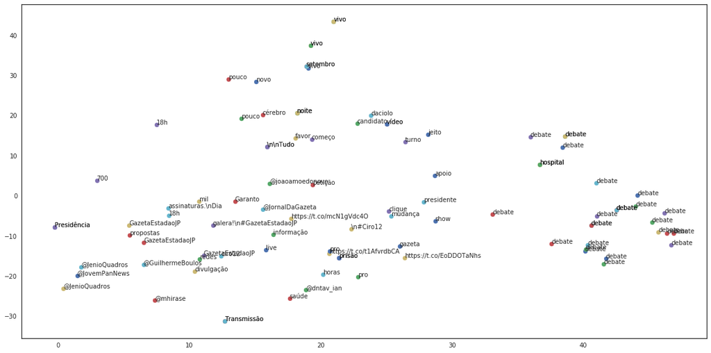

```python
fig, ax = plt.subplots(figsize=(20, 10))
xs, ys = lsa_out[:,0], lsa_out[:,1]
for i in range(len(xs)):
    plt.scatter(xs[i], ys[i])
    plt.annotate(tweets_noun_labels[i], (xs[i], ys[i]))
```

## 10. N-grams

### O que é?

Ao invés de considerar palavras individualmente (*unigram*), esta técnica consiste na análise de **conjuntos** de palavras em uma sentença, já que elas estão relacionadas entre si (premissa de [Markov](https://web.stanford.edu/~jurafsky/slp3/9.pdf))$^{1}$.

Comumente é utilizado **bi-gram**, **tri-gram**, **4-gram** e **5-gram** e, apesar de não ser suficiente já que as palavras de uma linguagem possuem relações "distantes" (*e.g.,* "que"), você vai conseguir ter muitos benefícios com sua utilização na grande maioria dos casos.

$^{1}$[Introduction to N-grams](https://web.stanford.edu/class/cs124/lec/languagemodeling2016.pdf)*

### Vamos construir ngrams para nossos *tweets*

Este método criar n-grams de qualquer **doc** spaCy a partir da quantidade **n** informada.

```python
def ngrams(doc, n):
    doc = [word for word in doc
           if word.is_alpha
           if not word.string.isupper()]
    return list(zip(*[doc[i:] for i in range(n)]))
```

Vamos ver o resultado!

```python
tweets_grams
```

```
{(no, hospital, Daciolo),
 (a, debate, Debate),
 (perca, o, debate),
 (bolsa, banqueiro, e),
 (Gazeta, e, Twitter),
 (de, agora, o),
 (a, pouco, tem),
 (atestado, para, não),
 (tem, debate, Fique),
 (Estão, anunciando, debate),
 (de, bilhões, no),
 (não, infringe, nenhuma),
 (poderia, ser, minimamente),
 (debate, de, presidenciáveis),
 (os, candidatos, à),
 (no, debate, Lula),
 (os, vai, Tô),
 (sem, Lula, preso),
 (do, Brasil, a),
 (debate, GazetaEstadaoJP, acompanhe),
 (bem, mais, articulado),
 (explíc, Ciro, se),
 (no, veja, o),
 (dragon, ball, no),
 (homem, Hoje, tem),
 (de, hoje, Não),
 (sobre, abuso, e),
 (qualidade, do, debate),
 (partir, das, tem),
 (tudo, aqui, no),
 (debate, eu, tacaria),
 (começo, Muito, ruim),
 (é, QuemMandouMatarBolsonaro, com),
 (do, debate, da),
 (pra, banco, hoje),
 (noite, teremos, o),
 (de, hoje, e),
 (de, que, o),
 (não, é, pra),
 (oração, e, jejum),
```

[output cut: 946 more lines]

```
 (n, este, domingo),
 (prisão, Bolsonaro, no),
 (vai, partir, d),
 (debate, de, hj),
 (comparar, as, propostas),
 (Massa, Amanhã, teremos),
 (bronhonaro, EuSoulula, e),
 (e, Neste, domingo),
 (das, conversas, Vergonha),
 (Vc, q, tem),
 (bem, da, minha),
 (após, o, ataque),
 (debate, enorme, na),
 (pena, essa, mistura),
 ...}
```

## 11. Pré-processamento de textos

### O que é?

Antes de podermos analisar sentimentos dos *tweets*, temos que tratar os textos.

Existem atividades "padrões" para o pré-processamento, vamos falar de todos eles ainda hoje:

1. Limpeza do texto
2. Tokenização
3. *Stemming* ou *Lemmatisation*

#### > Vocês reparam a quantidade de ruídos?

- Pontuações
- Letras maiúsculas e minúsculas
- Caracteres especiais

Além disso, existem palavras que não agregam relevância semântica (*e.g.,* "de", "para", "que", etc) **dado um cenário específico** de análise textual.

Essas palavras são chamadas de **stopwords**.

## > Conseguem me dizer um caso onde não podemos eliminar nenhuma palavra?

# ...VALENDO!

[figure not shown]

# SIM, CONTEXTO!

[figure not shown]

$^{1}$[Introduction to N-grams](https://web.stanford.edu/class/cs124/lec/languagemodeling2016.pdf)*

## *Stopwords*

Como lidamos com *stopwords* então?

Listamos todas as palavras "desnecessárias" na mão?

## Não! #tksGod

Todas as ferramentas de NLP possuem listas de *stopwords* para diferentes idiomas.

### PORÉM!

Para nosso querido idioma, Português, as listas existentes não costumam ser suficientes.

É bem comum ajustar a lista com novas *stopwords*.

No spaCy é bem simples utilizar *stopwords* também.

Vamos dar uma olhada na lista.

```python
print(STOP_WORDS)
```

```
{'adeus', 'nessa', 'uma', 'que', 'pegar', 'vens', 'sim', 'das', 'vezes', 'aí', 'todos', 'momento', 'ao', 'sétima', 'oitava', 'sei', 'fazemos', 'exemplo', 'quer', 'estiveram', 'tiveste', 'seria', 'vinda', 'tudo', 'isto', 'geral', 'fui', 'este', 'cinco', 'quarto', 'cada', 'debaixo', 'nossos', 'primeir…
```

Algo que temos bem específico em nosso *dataset*, não chega nem a ser uma palavra, mas também precisamos como *stopwords*.

## "RT" e "#"!

Vamos adicionar este "termo" à lista de *stopwords*.

Vamos ver quais palavras de nosso *dataset* são *stopwords* configurando nosso próprio atributo **"is_stop"**.

```python
from spacy.tokens import Token
```

```python
stop_words_getter = lambda token: token.is_stop or token.lower_ in STOP_WORDS or token.lemma_ in STOP_WORDS
```

```python
for word in STOP_WORDS:
    lexeme = nlp.vocab[word]
    lexeme.is_stop = True
```

Vamos printar cada palavra e identificar se é ou não uma *stopword*.

```python
for token in tweets_spacy:
```

```
0 0 False
              False
RT RT True
@MomentsBrasil @MomentsBrasil False
: : False
# # True
Eleições2018 Eleições2018 False
\n\nTudo \n\nTudo False
sobre sobrar True
o o False
debate debater False
entre entrar True
os o True
presidenciáveis presidenciáveis False
de de True
hoje hoje True
🗳 🗳 False
️ ️ False
\n\n \n\n False
📺 📺 False
Transmissão Transmissão False
em em True
vídeo vídeo False
a o False
o o False
vivo viver False
no o True
Twitter\n Twitter\n False
⚡ ⚡ False
️Twe ️Twe False
… … False


 False
1 1 False
                                                                                                                                                                                                                      False
RT RT True
@anyel @anyel False
: : False
@pdevechi @pdevechi False
```

[output cut: 12628 more lines]

```
… … False


 False
Name Name False
: : False
text text False
, , False
Length Length False
: : False
8822 8822 False
, , False
dtype dtype False
: : False
object object False
```

## *Stemming* e *Lemmatisation*$^{1}$

Muitas palavras possuem diferentes variações, principalmente em nosso idioma.

O verbo "estudar", por exemplo, pode ser utilizado em diferentes conjugações além da variação singular/plural:

- Estudo
- Estudei
- Estudaram
- Estudamos
- Etc.

#### Será que interpretar todas as palavras em todas as suas variações é o melhor cenário de NLP?

Não, né?

Justamente por isso existem técnicas para "normalizar" as palavras:

- *Stemming*: talvez a mais conhecida, é uma técnica responsável por reduzir uma palavra para sua **raiz gramatical**. Ou seja, independente de sua conjugação, a palavra estudar é sempre reduzida para **estud**. O *stemmer* mais conhecido é o de **Porter**. Essa técnica é a utilizada no [NLTK](http://www.nltk.org/howto/stem.html).
- *Lemmatisation*: ao invés de reduzir uma palavra par sua sua raiz gramatical, esta ténica consiste na redução para seu [**lema**](https://priberam.pt/dlpo/lema), ou seja, sua entrada de verbete em dicionários (*e.g.*, "estudei", "estudaram", "estudou", etc, ficariam sempre como **"estudar"**). Essa técnica é a utilizada pelo [spaCy](https://spacy.io/api/lemmatizer).

$^{1}$[Stemming and lemmatization](https://nlp.stanford.edu/IR-book/html/htmledition/stemming-and-lemmatization-1.html)*

Vamos ver como ficaria as palavras de nosso *córpus* após a *lemmetisation*.

```python
lemmas = [token.lemma_ for token in tweets_spacy if not token.is_stop ]
```

```python
lemmas = [lemma for lemma in lemmas if len(lemma)>2]
```

Vamos excluir "@" (menções) e "http" (links).

```python
lemmas = [lemma for lemma in lemmas if '@' not in lemma]
```

```python
lemmas = [lemma for lemma in lemmas if 'http' not in lemma]
```

Vamos ver como ficou.

```python
lemmas
```

```
['      ',
 'Eleições2018',
 '\\n\\nTudo',
 'debater',
 'presidenciáveis',
 '\\n\\n',
 'Transmissão',
 'vídeo',
 'viver',
 'Twitter\\n',
 '️Twe',
 '                                                                                                          ',
 'daciolo',
 'debater',
 '                                                                         ',
 'Arrisca',
 'debater',
 'produtivo',
 'turno',
 '           ',
 'Querem',
 'divulgação',
 'essencial',
 'pocs',
 'Ciro',
 'presidente',
 'Hoje',
 'debater',
 'gazeta',
 '           ',
 'Hoje',
 'ter',
 'debater',
 'presidencial',
 'esvaziar',
 'História',
 'Lula',
 'prisão',
 'Bolsonaro',
 'hospital',
```

[output cut: 946 more lines]

```
 'acontecer',
 'debater',
 'presidencial',
 'GazetaEstadaoJP',
 '115',
 '                                                                                                   ',
 'esquecer',
 'ter',
 'debater',
 'Gazeta',
 '116',
 '         ',
 'Últimos',
 'preparativo',
 ...]
```

Vamos construir um *dataframe* com os tokens *lemmetizados*.

```python
lemmas_df = pd.DataFrame(lemmas, columns={'token'})
```

```python
lemmas_df['token'] = lemmas_df['token'].apply(lambda x: x.replace('\\n', ''))
```

O método abaixo normaliza (*lowercase*, tokenização, lemmetização) os *tweets*.

```python
def normalizar(comment, lowercase, remove_stopwords):
    if lowercase:
        comment = comment.lower()
    comment = nlp(comment)
    lemmatized = list()
    for word in comment:
        lemma = word.lemma_.strip()
        if lemma:
            if not remove_stopwords or (remove_stopwords and lemma not in STOP_WORDS):
                lemmatized.append(lemma)
    return " ".join(lemmatized)
```

```python
%%time
```

```
CPU times: user 5min 40s, sys: 1h 12min 50s, total: 1h 18min 30s
Wall time: 1min 13s
```

Excluindo registros vazios.

```python
lemmas_df = lemmas_df.loc[lemmas_df['token'] != '']
```

Vamos ver o *dataframe*.

```python
lemmas_df.iloc[:10]
```

|  | token |
| --- | --- |
| 1 | eleições2018 |
| 3 | debater |
| 4 | presidenciáveis |
| 6 | transmissão |
| 7 | vídeo |
| 8 | viver |
| 9 | twitter |
| 10 | ️twe |
| 12 | daciolo |
| 13 | debater |

## *Wordcount* (TF)

Lembram que falamos que a forma mais antiga de vetorizar textos é a contagem de palavras (TF)?

É bem fácil fazer isso através de um **Counter()** do Python.

```python
wordcount = Counter(lemmas_df['token'])
```

Com ele conseguimos facilmente acessar as palavras mais comuns.

```python
wordcount.most_common(30)
```

```
[('debater', 441),
 ('gazetaestadaojp', 128),
 ('gazeta', 71),
 ('ciro12', 71),
 ('candidatar', 62),
 ('twitter', 59),
 ('presidenciáveis', 58),
 ('bolsonaro', 58),
 ('acompanhar', 51),
 ('viver', 43),
 ('ciro', 43),
 ('participar', 41),
 ('presidência', 37),
 ('brasil', 36),
 ('lula', 35),
 ('presidencial', 31),
 ('daciolo', 27),
 ('assistir', 25),
 ('bastidor', 23),
 ('18h', 23),
 ('domingo', 21),
 ('pra', 17),
 ('hospital', 16),
 ('perder', 16),
 ('perguntar', 16),
 ('acontecer', 16),
 ('gomar', 16),
 ('eleições2018', 15),
 ('esvaziar', 15),
 ('história', 15)]
```

Vamos transformar o Counter() em um *dataframe*.

```python
words = pd.DataFrame.from_dict(wordcount, orient='index').reset_index()
```

```python
words.rename(columns={'index':'token'}, inplace=True)
```

```python
words.rename(columns={0:'count'}, inplace=True)
```

Vamos transformar as palavras em **docs** do spaCy para acessar seus atributos linguísticos.

```python
%%time
```

```
CPU times: user 1min 34s, sys: 20min 30s, total: 22min 5s
Wall time: 20.8 s
```

```python
words.sort_values('count', ascending=False).iloc[:10]
```

|  | token | count |
| --- | --- | --- |
| 1 | (debater) | 441 |
| 35 | (gazetaestadaojp) | 128 |
| 18 | (gazeta) | 71 |
| 37 | (ciro12) | 71 |
| 42 | (candidatar) | 62 |
| 6 | (twitter) | 59 |
| 2 | (presidenciáveis) | 58 |
| 24 | (bolsonaro) | 58 |
| 33 | (acompanhar) | 51 |
| 5 | (viver) | 43 |

*(lembra da fórmula que vimos antes, né?)*

```python
words['freq'] = words['count'].apply(lambda x: x/len(words))
```

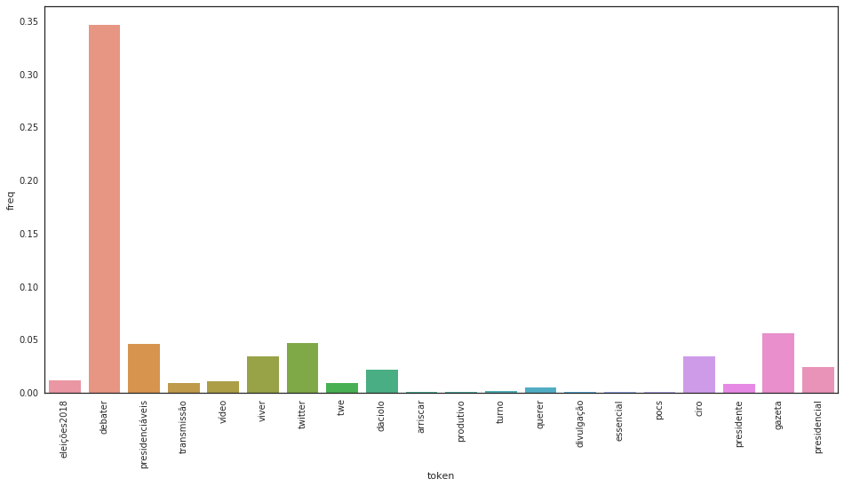

```python
sns.barplot(x=words.iloc[:20]['token'], y=words.iloc[:30]['freq'])
plt.xticks(rotation=90)
plt.show()
```

## Matrix de similaridade

Vamos aplicar o que já estudamos agora:

É legal fazer isso com o **doc** inteiro, mas cuidado com o tamanho dele.

Você vai conseguir plotar, mas a visualização vai ficar bem complicada!

```python
tmp_similaridade = words.iloc[:20]
```

```python
labels = words.iloc[:20]['token']
```

```python
similaridades_df = pd.DataFrame(similaridades, columns=labels, index=labels)
```

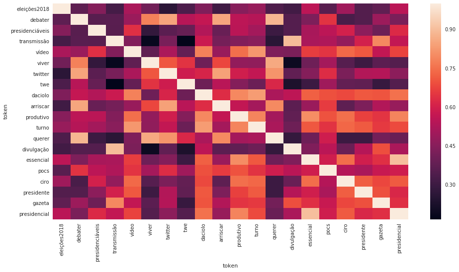

```python
rcParams['figure.figsize'] = 16, 8
sns.heatmap(similaridades_df)
plt.show()
```

## 12. Análise de Sentimentos$^{1}$$^{2}$

### O que é?

Antes de podermos analisar sentimentos dos *tweets*, temos que tratar os textos.

Existem atividades "padrões" para o pré-processamento, vamos falar de todos eles ainda hoje:

1. Limpeza do texto
2. Tokenização
3. *Stemming* ou *Lemmatisation*

Após ter textos tratados, podemos analisar sentimentos.

Já conversamos sobre como Inteligência Artificial não é mágica *(sorry again!)* e isso não é diferente em uma de suas grandes áreas: NLP.

A Análise de Sentimentos também é uma abordagem estatística, linguística e psico-comportamental para interpretar *sentimentos*, seja polaridade (positivo, negativo) ou multivariado (mais de duas classes).

Apesar de termos ótimos resultados em muitos casos simples, ainda estamos engatinhando com sentimentos complexos:

- [Humor](https://www.sciencedirect.com/science/article/pii/S0893608005000353) (raiva, alegria, decepção, indiferença, empatia, etc)
- [Ironia](https://www.sciencedirect.com/science/article/pii/S0169023X12000237)
- [Sarcasmo](https://arxiv.org/abs/1610.08815)
- [Piadas](http://www.aclweb.org/anthology/D15-1284)
- [Preconceito](https://link.springer.com/chapter/10.1007/978-3-319-73706-5_15)
- [Misoginia](https://link.springer.com/chapter/10.1007/978-3-319-91947-8_6)
- Etc.

Temos tido avanços muito significativos também com técnicas de [*Deep Learning*](https://nlp.stanford.edu/~socherr/EMNLP2013_RNTN.pdf).

Aqui o nosso foco será em uma classificação de sentimentos em *tweets* **positivos** e **negativos**.

$^{1}$[Sentiment analysis algorithms and applications: A survey](https://www.sciencedirect.com/science/article/pii/S2090447914000550)* $^{2}$[A survey on opinion mining and sentiment analysis: tasks, approaches and applications](https://www.sciencedirect.com/science/article/pii/S0950705115002336)*

## Pré-processar *tweets*

Até agora revisamos os conceitos necessários e utilizamos algumas sentenças para exemplificá-los.

Vamos aplicar o pré-processamento em todos os *tweets* para analisarmos os sentimentos.

#### Você não precisa executar o código abaixo, basta utilizar a coluna "text_clean" que deixei pronta para vocês!

```python
%%time
tweets['text_clean'] = tweets['text'].apply(normalizar, lowercase=True, remove_stopwords=True)
```

```
CPU times: user 2min 20s, sys: 1min 53s, total: 4min 13s
Wall time: 2min 12s
```

Vamos ver como ficou e comparar a diferença com o texto original:

```python
tweets.iloc[len(tweets)-10:len(tweets)][['text','text_clean']]
```

|  | text | text_clean |
| --- | --- | --- |
| 8812 | RT @EstadaoPolitica: Presidenciáveis participam do debate #GazetaEstadaoJP https://t.co/u9uv2C3dBy | @estadaopolitica : presidenciáveis participar debater gazetaestadaojp https://t.co/u9uv2c3dby |
| 8813 | Vem ver o debate! #Ciro12 #CiroPresidente12 #GazetaEstadaoJP | vir o debater ! ciro12 ciropresidente12 gazetaestadaojp |
| 8814 | RT @elpais_brasil: "Nós estamos num debate que faltam duas candidaturas. Uma por impedimento judicial e outra porque está no hospital. A vi… | @elpais_brasil : " nó debater faltar candidatura . umar impedimento judicial e o hospital . o vir … |
| 8815 | RT @BuzzFeedNewsBR: O maior número de menções no Twitter durante o debate #GazetaEstadaoJP é de @cirogomes, com 48% das menções (positivas… | @buzzfeednewsbr : o menção o twitter durante o debater gazetaestadaojp @cirogomes , 48 % menção ( positivo … |
| 8816 | Acho que se eu fosse candidato, e o mediador me interrompesse no debate, eu tacaria o púlpito na cara dele. DEIXA O POVO FALAR DESGRAÇA! | achar candidatar , e o mediador interromper o debater , tacar o púlpito o caro d . deixar o falar desgraçar ! |
| 8817 | Cirão se saindo muito bem no Debate !!!!!\n#Ciro12\n \n#GazetaEstadaoJP | cirão sair o debater ! ! ! ! ! ciro12 gazetaestadaojp |
| 8818 | RT @Ricamconsult: Hoje à noite, teremos o debate presidencial mais esvaziado da História. Lula na prisão, Bolsonaro no hospital, Daciolo de… | @ricamconsult : , o debater presidencial esvaziar história . lula o prisão , bolsonaro o hospital , daciolo … |
| 8819 | Pensa bem! | pensar ! |
| 8820 | #GazetaEstadaoJP de acorso com estatísticas, @cirogomes é o centro das atenções no debate, com 48% das menções no t… https://t.co/siKqe7k7Ee | gazetaestadaojp acorso estatístico , @cirogomes o centrar atenção o debater , 48 % menção o t … https://t.co/sikqe7k7ee |
| 8821 | RT @folha: "O Brasil permite que o baronato mantenha mais de R$ 500 bilhões no exterior sangrando esse país que trabalha e produz", diz Cir… | @folha : " o brasil permitir o baronato manter r$ 500 bilião o exterior sangrar país e produzir " , cir … |

## Base de treinamento

Como eu sou uma boa pessoa, eu rotulei manualmente alguns *tweets* para usarmos como treino.

[figure not shown]

Foram apenas poucos exemplos porque é apenas para a aula, mas na vida real você precisará de **muitos(!)** exemplos. Principalmente se quiser bancar o *popstar* com *Deep Learning*.

O arquivo **"tweets-train.csv"** possui uma coluna extra chamada **"sentiment"** onde:

- **1**: positivo
- **-1**: negativo

```python
tweets_train = pd.read_csv('data/debate_tweets-train.csv', encoding='utf-8')
```

```python
print(len(tweets_train.loc[tweets_train['sentiment']==-1]))
print(len(tweets_train.loc[tweets_train['sentiment']==1]))
```

```
44
44
```

Vamos utilizar apenas o **texto** do *tweet* e o sentimento identificado.

```python
filtro = ['text_clean', 'sentiment']
```

```python
train_set = tweets_train[filtro]
```

## Classificação supervisionada

Vamos utilizar um algoritmo que vocês já conhecem e também é muito utilizado:

- Árvore de Decisão *(Random Forest)*

Importando o que precisamos.

```python
from sklearn.model_selection import train_test_split
from sklearn.pipeline import Pipeline
from sklearn.feature_extraction.text import CountVectorizer
from sklearn.feature_extraction.text import TfidfTransformer
from sklearn.model_selection import cross_validate
from sklearn import metrics
```

### Árvore de Decisão

```python
from sklearn.ensemble import RandomForestClassifier
```

Vamos utilizar o conceito de *pipelines* que o scikit nos proporciona.

Nele construímos um *"workflow"* das atividades que queremos executar ao invés de executá-las manualmente uma a uma. No nosso caso:

- Vetorização de ocorrências;
- TF-IDF;
- Modelo de classificação supervisionada (DT, NN)

```python
%%time
rf_pl = Pipeline([ ('vect', CountVectorizer()),
                   ('tfidf', TfidfTransformer()),
                   ('clf', RandomForestClassifier())
                 ])
```

```
CPU times: user 0 ns, sys: 0 ns, total: 0 ns
Wall time: 245 µs
```

Vamos dividir nossa base em **treino** e **teste**.

```python
train_df, test_df = train_test_split(train_set, test_size=0.3)
```

Vamos ocultar a **classe** na base de treino e converter os *dataframes* para **"ndarray"** (input dos algoritmos).

Também vamos ocultar a classe da base de teste e guardá-la para avaliação.

```python
X = train_df[train_df.columns[0:len(train_df.axes[1])-1]].values.ravel()
y = train_df.sentiment
y_test = test_df[test_df.columns[0:len(test_df.axes[1])-1]].values.ravel()
```

Agora podemos treinar nossa Árvore de Decisão.

```python
%%time
```

```
CPU times: user 20 ms, sys: 0 ns, total: 20 ms
Wall time: 18.4 ms
```

```
Pipeline(memory=None,
     steps=[('vect', CountVectorizer(analyzer='word', binary=False, decode_error='strict',
        dtype=<class 'numpy.int64'>, encoding='utf-8', input='content',
        lowercase=True, max_df=1.0, max_features=None, min_df=1,
        ngram_range=(1, 1), preprocessor=None, stop_words=None,
        strip...n_jobs=1,
            oob_score=False, random_state=None, verbose=0,
            warm_start=False))])
```

Com o modelo treinado, podemos testá-lo na base separada de teste sem rótulos:

```python
rf_predicted = rf_pl.predict(y_test)
```

E comparar o resultado com os rótulos corretos que guardamos:

```
0.6666666666666666
```

Podemos exibir os resultados através das métricas de avaliação do modelo:

- Precisão
- Cobertura
- F-measure

```python
print(metrics.classification_report(test_df.sentiment, rf_predicted))
```

```
             precision    recall  f1-score   support

         -1       0.65      0.79      0.71        14
          1       0.70      0.54      0.61        13

avg / total       0.67      0.67      0.66        27
```

Ou a matrix de confusão com:

$\begin{bmatrix}TP & FN\\FP & TN\end{bmatrix}$

Onde:

- **TP**: true positive
- **FN**: false negative
- **FP**: false positive
- **TN**: true negative

```python
print(metrics.confusion_matrix(test_df.sentiment, rf_predicted))
```

```
[[11  3]
 [ 6  7]]
```

É muito comum precisar trabalhar no *fine tuning* de um algoritmo.

Você pode encontrar um cenário onde precise trabalhar no ajuste de **FP's**, por exemplo.

#### Então é necessário observar exemplos de erros do algoritmo.

Vamos adicionar uma nova coluna ao *dataframe* de teste com os rótulos que o modelo sugeriu.

```python
test_df['pred'] = rf_predicted
```

Agora conseguimos obserar os erros e tentar entender porquê o modelo falhou.

Lembrando que o modelo não falha porque é ruim, mas porque **você** falhou em fornecer exemplos suficientemente representativos.

[figure not shown]

```python
test_df.loc[test_df.sentiment != test_df.pred]
```

|  | text_clean | sentiment | pred |
| --- | --- | --- | --- |
| 44 | @cidfgomes : debater ! ficar atentar , o 18h , o tv gazeta . assistir e divulgar ! ciro12 https://t.co/e7st8tommv | 1 | -1 |
| 53 | caramba , e debater acontecer ? gazetaestadaojp | -1 | 1 |
| 39 | assistir o debater só esperar meme @cirogomes https://t.co/kf1ecfd4oo | 1 | -1 |
| 32 | rapaz , e debater o gazeta | 1 | -1 |
| 31 | debater presidencial @estadao e bolsoanro pagar mico . | 1 | -1 |
| 10 | pra bolsonaro ganhar o eleição , comparar o audiência debater , o … https://t.co/kpebaha5wv | 1 | -1 |
| 5 | ruim debater saudar parir o debater | -1 | 1 |
| 69 | ceis animar pra debater pleno domingo | 1 | -1 |
| 76 | marino , pt igual o o psdb assaltar petrobras , caixa , correio , banco brasil , bndes corretar . q … https://t.co/eapqmfxzrd | -1 | 1 |

# Fim.

[figure not shown]

## O que fazer agora?

Segue uma lista de **desafios** como próximos passos:

1. Rotular mais exemplos ([*Mechanical Turk?*](https://www.mturk.com))
2. Testar outros algoritmos de classificação (Bayes, NN, SVM, LSTM, etc)
3. Analisar [*emojis*](https://pypi.org/project/Emojipedia/)
4. Classificar sentimentos 'reais'
5. [Modelagem de Tópicos](http://cjc.ict.ac.cn/eng/qwjse/view.asp?id=2616) (LDA)
6. [word2vec](https://arxiv.org/pdf/1411.2738v4.pdf)
7. Visualizar word2vec com [*t-Distributed Stochastic Neighbor Embedding*](https://lvdmaaten.github.io/publications/papers/JMLR_2008.pdf) (t-SNE)

[figure not shown]